# **An evalutation of Fighters in the UFC**

Collaborators: Mason Paradise and Conor Syme

### **Introduction**

This tutorial aims to explore the complete data science lifecycle, delving into the intricacies of statistical analysis to uncover insights within the realm of UFC (Ultimate Fighting Championship) fighters. As aficionados of the sport, we are intrigued by the factors that contribute to the success of certain fighters over others, as well as the potential trends prevalent across different weight classes. With the UFC standing as the pinnacle of mixed martial arts (MMA) globally, boasting a rich history since its inception in 1993, our journey through the data science process will illuminate the evolution of this highly regulated, multi-billion dollar enterprise. From its humble beginnings as a showcase of diverse fighting styles to its current status as a platform for the world's premier athletes, the UFC encompasses a myriad of disciplines including Brazilian Jiu-Jitsu, wrestling, Muay Thai, and boxing, offering a fertile ground for statistical exploration. Through meticulous analysis, we seek to unravel the underlying relationships and trends embedded within the data, shedding light on the nuanced factors that shape the success trajectories of UFC fighters across various weight divisions. By leveraging statistical techniques, we aspire to provide actionable insights that not only deepen our understanding of the sport but also contribute to the ongoing discourse surrounding MMA competition.

In this tutorial we will be going through the different parts of the data science lifecycle

1. Data Collection
2. Data processing
3. Exploratory Data Anaylsis (EDA) & Data Visualization
4. Model: Analysis, Hypothesis testing, & Machine Learning
5. Interpretation: Insight & Policy Decision

### **1. Data Collection**

In the data collection phase of the data science lifecycle, we have to find a dataset. We were able to find a dataset that we could use to perfrom the analysis from kaggle. The dataset is called [UFC Fighters' Statistics 2024](https://www.kaggle.com/datasets/aaronfriasr/ufc-fighters-statistics/data) and it has information on 4111 different fighters who have once fought for the UFC as recently as this year. It has 18 columns of information including height, weight, fighting stance, and many other striking and takedown statistics.

For this tutorial and analysis, the programming language we will be using is Python. The tools will be using are Jupyter Notebook and many different APIs such as Pandas, NumPy, and matplotlib. These tools will be used to create the tutorial as well as easily provide information on all of the different data provided.

```python
from google.colab import drive
drive.mount('/content/drive')
```

```python
import pandas as pd
import numpy as np
import matplotlib.pyplot as plt
import seaborn as sns
from sklearn.model_selection import train_test_split
from sklearn.linear_model import LinearRegression, RANSACRegressor
```

```python
df = pd.read_csv("/content/drive/MyDrive/ufc-fighters-statistics.csv")

df.head()
```

|  | name | nickname | wins | losses | draws | height_cm | weight_in_kg | reach_in_cm | stance | date_of_birth | significant_strikes_landed_per_minute | significant_striking_accuracy | significant_strikes_absorbed_per_minute | significant_strike_defence | average_takedowns_landed_per_15_minutes | takedown_accuracy | takedown_defense | average_submissions_attempted_per_15_minutes |
| --- | --- | --- | --- | --- | --- | --- | --- | --- | --- | --- | --- | --- | --- | --- | --- | --- | --- | --- |
| 0 | Robert Drysdale | NaN | 7 | 0 | 0 | 190.50 | 92.99 | NaN | Orthodox | 1981-10-05 | 0.00 | 0.0 | 0.00 | 0.0 | 7.32 | 100.0 | 0.0 | 21.9 |
| 1 | Daniel McWilliams | The Animal | 15 | 37 | 0 | 185.42 | 83.91 | NaN | NaN | NaN | 3.36 | 77.0 | 0.00 | 0.0 | 0.00 | 0.0 | 100.0 | 21.6 |
| 2 | Dan Molina | NaN | 13 | 9 | 0 | 177.80 | 97.98 | NaN | NaN | NaN | 0.00 | 0.0 | 5.58 | 60.0 | 0.00 | 0.0 | 0.0 | 20.9 |
| 3 | Paul Ruiz | NaN | 7 | 4 | 0 | 167.64 | 61.23 | NaN | NaN | NaN | 1.40 | 33.0 | 1.40 | 75.0 | 0.00 | 0.0 | 100.0 | 20.9 |
| 4 | Collin Huckbody | All In | 8 | 2 | 0 | 190.50 | 83.91 | 193.04 | Orthodox | 1994-09-29 | 2.05 | 60.0 | 2.73 | 42.0 | 10.23 | 100.0 | 0.0 | 20.4 |

```python
df.describe()
```

|  | wins | losses | draws | height_cm | weight_in_kg | reach_in_cm | significant_strikes_landed_per_minute | significant_striking_accuracy | significant_strikes_absorbed_per_minute | significant_strike_defence | average_takedowns_landed_per_15_minutes | takedown_accuracy | takedown_defense | average_submissions_attempted_per_15_minutes |
| --- | --- | --- | --- | --- | --- | --- | --- | --- | --- | --- | --- | --- | --- | --- |
| count | 4111.000000 | 4111.000000 | 4111.000000 | 3813.000000 | 4024.000000 | 2184.000000 | 4111.000000 | 4111.000000 | 4111.000000 | 4111.000000 | 4111.000000 | 4111.000000 | 4111.000000 | 4111.000000 |
| mean | 12.366821 | 5.726344 | 0.264413 | 178.234325 | 77.395825 | 181.808874 | 2.437516 | 35.542447 | 3.145206 | 42.643639 | 1.250586 | 26.299927 | 38.958891 | 0.610095 |
| std | 9.374667 | 5.103768 | 0.822373 | 8.888050 | 17.982242 | 10.680804 | 1.990903 | 20.398502 | 2.848502 | 22.322427 | 1.935716 | 28.700980 | 34.426458 | 1.505924 |
| min | 0.000000 | 0.000000 | 0.000000 | 152.400000 | 47.630000 | 147.320000 | 0.000000 | 0.000000 | 0.000000 | 0.000000 | 0.000000 | 0.000000 | 0.000000 | 0.000000 |
| 25% | 7.000000 | 2.000000 | 0.000000 | 172.720000 | 65.770000 | 175.260000 | 0.830000 | 27.000000 | 1.550000 | 36.000000 | 0.000000 | 0.000000 | 0.000000 | 0.000000 |
| 50% | 11.000000 | 5.000000 | 0.000000 | 177.800000 | 77.110000 | 182.880000 | 2.330000 | 40.000000 | 2.940000 | 50.000000 | 0.590000 | 22.000000 | 42.000000 | 0.000000 |
| 75% | 17.000000 | 8.000000 | 0.000000 | 185.420000 | 83.910000 | 190.500000 | 3.600000 | 49.000000 | 4.230000 | 58.000000 | 1.940000 | 45.000000 | 66.000000 | 0.700000 |
| max | 253.000000 | 83.000000 | 11.000000 | 226.060000 | 349.270000 | 213.360000 | 17.650000 | 100.000000 | 52.500000 | 100.000000 | 32.140000 | 100.000000 | 100.000000 | 21.900000 |

### **2. Data processing**

While this dataset is already very organized and neat, there are still some things that need to be done to get a clean dataset. First off, we need to remove some rows. The rows that we want to remove are of fighters who have NaN for height and weight. We are removing these rows to more get more accurate data when we perform our analysis and also because all of the fighters that matter have a value for height and weight.

```python
df = df.dropna(subset=['height_cm','weight_in_kg'])
df.head()
```

|  | name | nickname | wins | losses | draws | height_cm | weight_in_kg | reach_in_cm | stance | date_of_birth | significant_strikes_landed_per_minute | significant_striking_accuracy | significant_strikes_absorbed_per_minute | significant_strike_defence | average_takedowns_landed_per_15_minutes | takedown_accuracy | takedown_defense | average_submissions_attempted_per_15_minutes |
| --- | --- | --- | --- | --- | --- | --- | --- | --- | --- | --- | --- | --- | --- | --- | --- | --- | --- | --- |
| 0 | Robert Drysdale | NaN | 7 | 0 | 0 | 190.50 | 92.99 | NaN | Orthodox | 1981-10-05 | 0.00 | 0.0 | 0.00 | 0.0 | 7.32 | 100.0 | 0.0 | 21.9 |
| 1 | Daniel McWilliams | The Animal | 15 | 37 | 0 | 185.42 | 83.91 | NaN | NaN | NaN | 3.36 | 77.0 | 0.00 | 0.0 | 0.00 | 0.0 | 100.0 | 21.6 |
| 2 | Dan Molina | NaN | 13 | 9 | 0 | 177.80 | 97.98 | NaN | NaN | NaN | 0.00 | 0.0 | 5.58 | 60.0 | 0.00 | 0.0 | 0.0 | 20.9 |
| 3 | Paul Ruiz | NaN | 7 | 4 | 0 | 167.64 | 61.23 | NaN | NaN | NaN | 1.40 | 33.0 | 1.40 | 75.0 | 0.00 | 0.0 | 100.0 | 20.9 |
| 4 | Collin Huckbody | All In | 8 | 2 | 0 | 190.50 | 83.91 | 193.04 | Orthodox | 1994-09-29 | 2.05 | 60.0 | 2.73 | 42.0 | 10.23 | 100.0 | 0.0 | 20.4 |

Now that we have removed all of the fighters without a recorded weight or height, we will now check to see if there are any duplicate fighters. To check for duplicate fighters we check to see if name, nickname, and date of birth are all the same. As you can see, there are no duplicated fighters in the dataset.

```python
df.loc[df.duplicated(subset = ['name','nickname','date_of_birth'])]
```

|  | name | nickname | wins | losses | draws | height_cm | weight_in_kg | reach_in_cm | stance | date_of_birth | significant_strikes_landed_per_minute | significant_striking_accuracy | significant_strikes_absorbed_per_minute | significant_strike_defence | average_takedowns_landed_per_15_minutes | takedown_accuracy | takedown_defense | average_submissions_attempted_per_15_minutes |
| --- | --- | --- | --- | --- | --- | --- | --- | --- | --- | --- | --- | --- | --- | --- | --- | --- | --- | --- |

Now that we checked to see if there were any duplicate fighters, we can see that there are now 3807 different fighters compared to the 4111 fighters from the original dataset. That is a difference of 304 fighters.

```python
df.describe()
```

|  | wins | losses | draws | height_cm | weight_in_kg | reach_in_cm | significant_strikes_landed_per_minute | significant_striking_accuracy | significant_strikes_absorbed_per_minute | significant_strike_defence | average_takedowns_landed_per_15_minutes | takedown_accuracy | takedown_defense | average_submissions_attempted_per_15_minutes |
| --- | --- | --- | --- | --- | --- | --- | --- | --- | --- | --- | --- | --- | --- | --- |
| count | 3807.000000 | 3807.000000 | 3807.000000 | 3807.000000 | 3807.000000 | 2183.000000 | 3807.000000 | 3807.000000 | 3807.000000 | 3807.000000 | 3807.000000 | 3807.000000 | 3807.000000 | 3807.000000 |
| mean | 12.977410 | 5.901497 | 0.279485 | 178.231673 | 77.507402 | 181.810710 | 2.596501 | 37.726819 | 3.317759 | 45.180457 | 1.318668 | 27.983189 | 41.616233 | 0.642133 |
| std | 9.375874 | 5.067958 | 0.848266 | 8.881753 | 18.217766 | 10.682906 | 1.956328 | 18.950262 | 2.824519 | 20.352626 | 1.931193 | 28.705020 | 33.944432 | 1.530281 |
| min | 0.000000 | 0.000000 | 0.000000 | 152.400000 | 47.630000 | 147.320000 | 0.000000 | 0.000000 | 0.000000 | 0.000000 | 0.000000 | 0.000000 | 0.000000 | 0.000000 |
| 25% | 7.000000 | 3.000000 | 0.000000 | 172.720000 | 65.770000 | 175.260000 | 1.165000 | 31.000000 | 1.860000 | 40.000000 | 0.000000 | 0.000000 | 0.000000 | 0.000000 |
| 50% | 11.000000 | 5.000000 | 0.000000 | 177.800000 | 77.110000 | 182.880000 | 2.500000 | 41.000000 | 3.030000 | 51.000000 | 0.720000 | 25.000000 | 48.000000 | 0.000000 |
| 75% | 17.000000 | 8.000000 | 0.000000 | 185.420000 | 83.910000 | 190.500000 | 3.690000 | 50.000000 | 4.315000 | 58.000000 | 2.000000 | 46.000000 | 68.000000 | 0.800000 |
| max | 253.000000 | 83.000000 | 11.000000 | 226.060000 | 349.270000 | 213.360000 | 17.650000 | 100.000000 | 52.500000 | 100.000000 | 32.140000 | 100.000000 | 100.000000 | 21.900000 |

With our dataset of only fighters we want to perform the analysis on, we now want to make a new column for total fights for each fighter. The way we do this is by adding up the number of wins, draws, and loses.

```python
df['total_fights'] = df['wins'] + df['losses'] + df['draws']
tmp_col = df.pop('total_fights')
df.insert(5, 'total_fights', tmp_col)
df.head()
```

|  | name | nickname | wins | losses | draws | total_fights | height_cm | weight_in_kg | reach_in_cm | stance | date_of_birth | significant_strikes_landed_per_minute | significant_striking_accuracy | significant_strikes_absorbed_per_minute | significant_strike_defence | average_takedowns_landed_per_15_minutes | takedown_accuracy | takedown_defense | average_submissions_attempted_per_15_minutes |
| --- | --- | --- | --- | --- | --- | --- | --- | --- | --- | --- | --- | --- | --- | --- | --- | --- | --- | --- | --- |
| 0 | Robert Drysdale | NaN | 7 | 0 | 0 | 7 | 190.50 | 92.99 | NaN | Orthodox | 1981-10-05 | 0.00 | 0.0 | 0.00 | 0.0 | 7.32 | 100.0 | 0.0 | 21.9 |
| 1 | Daniel McWilliams | The Animal | 15 | 37 | 0 | 52 | 185.42 | 83.91 | NaN | NaN | NaN | 3.36 | 77.0 | 0.00 | 0.0 | 0.00 | 0.0 | 100.0 | 21.6 |
| 2 | Dan Molina | NaN | 13 | 9 | 0 | 22 | 177.80 | 97.98 | NaN | NaN | NaN | 0.00 | 0.0 | 5.58 | 60.0 | 0.00 | 0.0 | 0.0 | 20.9 |
| 3 | Paul Ruiz | NaN | 7 | 4 | 0 | 11 | 167.64 | 61.23 | NaN | NaN | NaN | 1.40 | 33.0 | 1.40 | 75.0 | 0.00 | 0.0 | 100.0 | 20.9 |
| 4 | Collin Huckbody | All In | 8 | 2 | 0 | 10 | 190.50 | 83.91 | 193.04 | Orthodox | 1994-09-29 | 2.05 | 60.0 | 2.73 | 42.0 | 10.23 | 100.0 | 0.0 | 20.4 |

Along with total fights for each fighter, we want the win percentage of each fighter. We get this by wins divided by total fights multiplied by 100.

```python
df['win_percentage'] = df['wins'] / df['total_fights'] * 100
tmp_col = df.pop('win_percentage')
df.insert(6, 'win_percentage', tmp_col)
df.head()
```

|  | name | nickname | wins | losses | draws | total_fights | win_percentage | height_cm | weight_in_kg | reach_in_cm | stance | date_of_birth | significant_strikes_landed_per_minute | significant_striking_accuracy | significant_strikes_absorbed_per_minute | significant_strike_defence | average_takedowns_landed_per_15_minutes | takedown_accuracy | takedown_defense | average_submissions_attempted_per_15_minutes |
| --- | --- | --- | --- | --- | --- | --- | --- | --- | --- | --- | --- | --- | --- | --- | --- | --- | --- | --- | --- | --- |
| 0 | Robert Drysdale | NaN | 7 | 0 | 0 | 7 | 100.000000 | 190.50 | 92.99 | NaN | Orthodox | 1981-10-05 | 0.00 | 0.0 | 0.00 | 0.0 | 7.32 | 100.0 | 0.0 | 21.9 |
| 1 | Daniel McWilliams | The Animal | 15 | 37 | 0 | 52 | 28.846154 | 185.42 | 83.91 | NaN | NaN | NaN | 3.36 | 77.0 | 0.00 | 0.0 | 0.00 | 0.0 | 100.0 | 21.6 |
| 2 | Dan Molina | NaN | 13 | 9 | 0 | 22 | 59.090909 | 177.80 | 97.98 | NaN | NaN | NaN | 0.00 | 0.0 | 5.58 | 60.0 | 0.00 | 0.0 | 0.0 | 20.9 |
| 3 | Paul Ruiz | NaN | 7 | 4 | 0 | 11 | 63.636364 | 167.64 | 61.23 | NaN | NaN | NaN | 1.40 | 33.0 | 1.40 | 75.0 | 0.00 | 0.0 | 100.0 | 20.9 |
| 4 | Collin Huckbody | All In | 8 | 2 | 0 | 10 | 80.000000 | 190.50 | 83.91 | 193.04 | Orthodox | 1994-09-29 | 2.05 | 60.0 | 2.73 | 42.0 | 10.23 | 100.0 | 0.0 | 20.4 |

The next thing we need to do is turn the date_of_birth column into a column for the age of each fighter. Having a column for age will be easier to understand than having a column for when each fighter was born.

To get a column for age, we need to first change the object type in the date_of_birth column into datetime. From that we can get the year for each fighter and subtract that from 2024 to get each fighters age. Once we have the age column, we can delete the date_of_birth column and move the age column to where date_of_birth was.

```python
df['date_of_birth'] = pd.to_datetime(df['date_of_birth'])
df['age'] = 2024 - df['date_of_birth'].dt.year
```

```python
tmp_col = df.pop('age')
df.insert(11, 'age', tmp_col)
del df['date_of_birth']

df.head()
```

|  | name | nickname | wins | losses | draws | total_fights | win_percentage | height_cm | weight_in_kg | reach_in_cm | stance | age | significant_strikes_landed_per_minute | significant_striking_accuracy | significant_strikes_absorbed_per_minute | significant_strike_defence | average_takedowns_landed_per_15_minutes | takedown_accuracy | takedown_defense | average_submissions_attempted_per_15_minutes |
| --- | --- | --- | --- | --- | --- | --- | --- | --- | --- | --- | --- | --- | --- | --- | --- | --- | --- | --- | --- | --- |
| 0 | Robert Drysdale | NaN | 7 | 0 | 0 | 7 | 100.000000 | 190.50 | 92.99 | NaN | Orthodox | 43.0 | 0.00 | 0.0 | 0.00 | 0.0 | 7.32 | 100.0 | 0.0 | 21.9 |
| 1 | Daniel McWilliams | The Animal | 15 | 37 | 0 | 52 | 28.846154 | 185.42 | 83.91 | NaN | NaN | NaN | 3.36 | 77.0 | 0.00 | 0.0 | 0.00 | 0.0 | 100.0 | 21.6 |
| 2 | Dan Molina | NaN | 13 | 9 | 0 | 22 | 59.090909 | 177.80 | 97.98 | NaN | NaN | NaN | 0.00 | 0.0 | 5.58 | 60.0 | 0.00 | 0.0 | 0.0 | 20.9 |
| 3 | Paul Ruiz | NaN | 7 | 4 | 0 | 11 | 63.636364 | 167.64 | 61.23 | NaN | NaN | NaN | 1.40 | 33.0 | 1.40 | 75.0 | 0.00 | 0.0 | 100.0 | 20.9 |
| 4 | Collin Huckbody | All In | 8 | 2 | 0 | 10 | 80.000000 | 190.50 | 83.91 | 193.04 | Orthodox | 30.0 | 2.05 | 60.0 | 2.73 | 42.0 | 10.23 | 100.0 | 0.0 | 20.4 |

Now that we have each fighters' age, we now want to convert the height from cm to feet. While cm might be helpful for some people, we are American and will understand feet more. Once the column height_ft is created, we will then delete the height_cm column.

```python
df['inches'] = df['height_cm'] / 2.54
df['feet'] = df['inches'] / 12
tmp_col = df.pop('feet')
df.insert(7, 'height_ft', tmp_col)
del df['inches']
del df['height_cm']
df.head()
```

|  | name | nickname | wins | losses | draws | total_fights | win_percentage | height_ft | weight_in_kg | reach_in_cm | stance | age | significant_strikes_landed_per_minute | significant_striking_accuracy | significant_strikes_absorbed_per_minute | significant_strike_defence | average_takedowns_landed_per_15_minutes | takedown_accuracy | takedown_defense | average_submissions_attempted_per_15_minutes |
| --- | --- | --- | --- | --- | --- | --- | --- | --- | --- | --- | --- | --- | --- | --- | --- | --- | --- | --- | --- | --- |
| 0 | Robert Drysdale | NaN | 7 | 0 | 0 | 7 | 100.000000 | 6.250000 | 92.99 | NaN | Orthodox | 43.0 | 0.00 | 0.0 | 0.00 | 0.0 | 7.32 | 100.0 | 0.0 | 21.9 |
| 1 | Daniel McWilliams | The Animal | 15 | 37 | 0 | 52 | 28.846154 | 6.083333 | 83.91 | NaN | NaN | NaN | 3.36 | 77.0 | 0.00 | 0.0 | 0.00 | 0.0 | 100.0 | 21.6 |
| 2 | Dan Molina | NaN | 13 | 9 | 0 | 22 | 59.090909 | 5.833333 | 97.98 | NaN | NaN | NaN | 0.00 | 0.0 | 5.58 | 60.0 | 0.00 | 0.0 | 0.0 | 20.9 |
| 3 | Paul Ruiz | NaN | 7 | 4 | 0 | 11 | 63.636364 | 5.500000 | 61.23 | NaN | NaN | NaN | 1.40 | 33.0 | 1.40 | 75.0 | 0.00 | 0.0 | 100.0 | 20.9 |
| 4 | Collin Huckbody | All In | 8 | 2 | 0 | 10 | 80.000000 | 6.250000 | 83.91 | 193.04 | Orthodox | 30.0 | 2.05 | 60.0 | 2.73 | 42.0 | 10.23 | 100.0 | 0.0 | 20.4 |

We will now convert weight from kg to lb similar to what we did for height, and delete the weight_in_kg column.

```python
df['weight_lb'] = df['weight_in_kg'] * 2.20462262
tmp_col = df.pop('weight_lb')
df.insert(8, 'weight_lb', tmp_col)
del df['weight_in_kg']

df.head()
```

|  | name | nickname | wins | losses | draws | total_fights | win_percentage | height_ft | weight_lb | reach_in_cm | stance | age | significant_strikes_landed_per_minute | significant_striking_accuracy | significant_strikes_absorbed_per_minute | significant_strike_defence | average_takedowns_landed_per_15_minutes | takedown_accuracy | takedown_defense | average_submissions_attempted_per_15_minutes |
| --- | --- | --- | --- | --- | --- | --- | --- | --- | --- | --- | --- | --- | --- | --- | --- | --- | --- | --- | --- | --- |
| 0 | Robert Drysdale | NaN | 7 | 0 | 0 | 7 | 100.000000 | 6.250000 | 205.007857 | NaN | Orthodox | 43.0 | 0.00 | 0.0 | 0.00 | 0.0 | 7.32 | 100.0 | 0.0 | 21.9 |
| 1 | Daniel McWilliams | The Animal | 15 | 37 | 0 | 52 | 28.846154 | 6.083333 | 184.989884 | NaN | NaN | NaN | 3.36 | 77.0 | 0.00 | 0.0 | 0.00 | 0.0 | 100.0 | 21.6 |
| 2 | Dan Molina | NaN | 13 | 9 | 0 | 22 | 59.090909 | 5.833333 | 216.008924 | NaN | NaN | NaN | 0.00 | 0.0 | 5.58 | 60.0 | 0.00 | 0.0 | 0.0 | 20.9 |
| 3 | Paul Ruiz | NaN | 7 | 4 | 0 | 11 | 63.636364 | 5.500000 | 134.989043 | NaN | NaN | NaN | 1.40 | 33.0 | 1.40 | 75.0 | 0.00 | 0.0 | 100.0 | 20.9 |
| 4 | Collin Huckbody | All In | 8 | 2 | 0 | 10 | 80.000000 | 6.250000 | 184.989884 | 193.04 | Orthodox | 30.0 | 2.05 | 60.0 | 2.73 | 42.0 | 10.23 | 100.0 | 0.0 | 20.4 |

Now we are going to convert the reach of each fighter from cm to feet and inches just like we did for height. We also are going to make it so that each statistic has only two decimal places.

```python
df['inches'] = df['reach_in_cm'] / 2.54
df['feet'] = df['inches'] / 12
tmp_col = df.pop('feet')
df.insert(9, 'reach_ft', tmp_col)
del df['inches']
del df['reach_in_cm']
df = df.round(2)
df.head()
```

|  | name | nickname | wins | losses | draws | total_fights | win_percentage | height_ft | weight_lb | reach_ft | stance | age | significant_strikes_landed_per_minute | significant_striking_accuracy | significant_strikes_absorbed_per_minute | significant_strike_defence | average_takedowns_landed_per_15_minutes | takedown_accuracy | takedown_defense | average_submissions_attempted_per_15_minutes |
| --- | --- | --- | --- | --- | --- | --- | --- | --- | --- | --- | --- | --- | --- | --- | --- | --- | --- | --- | --- | --- |
| 0 | Robert Drysdale | NaN | 7 | 0 | 0 | 7 | 100.00 | 6.25 | 205.01 | NaN | Orthodox | 43.0 | 0.00 | 0.0 | 0.00 | 0.0 | 7.32 | 100.0 | 0.0 | 21.9 |
| 1 | Daniel McWilliams | The Animal | 15 | 37 | 0 | 52 | 28.85 | 6.08 | 184.99 | NaN | NaN | NaN | 3.36 | 77.0 | 0.00 | 0.0 | 0.00 | 0.0 | 100.0 | 21.6 |
| 2 | Dan Molina | NaN | 13 | 9 | 0 | 22 | 59.09 | 5.83 | 216.01 | NaN | NaN | NaN | 0.00 | 0.0 | 5.58 | 60.0 | 0.00 | 0.0 | 0.0 | 20.9 |
| 3 | Paul Ruiz | NaN | 7 | 4 | 0 | 11 | 63.64 | 5.50 | 134.99 | NaN | NaN | NaN | 1.40 | 33.0 | 1.40 | 75.0 | 0.00 | 0.0 | 100.0 | 20.9 |
| 4 | Collin Huckbody | All In | 8 | 2 | 0 | 10 | 80.00 | 6.25 | 184.99 | 6.33 | Orthodox | 30.0 | 2.05 | 60.0 | 2.73 | 42.0 | 10.23 | 100.0 | 0.0 | 20.4 |

Now that the height, weight, and reach are converted to US system of units. We want to create a column for the weightclass of each fighter. The UFC currently has 9 different weight classes. These weight classes are Strawweight (115 lbs), Flyweight (125 lbs), Bantamweight (135 lbs), Featherweight (145 lbs), Lightweight (155 lbs), Welterweight (170 lbs), Middleweight (185 lbs), Light Heavyweight (205 lbs), and Heavyweight (265 lbs). The first 4 weight classes cover women's weight classes, and men's is flyweight and above. For some fighters, their weights are 0.01 above a certain weight class so we had to make sure that those fighters were assigned to the right weight class.

```python
weight_classes = {'Strawweight':115,
'Flyweight':125,
'Bantamweight':	135,
'Featherweight': 145,
'Lightweight':155,
'Welterweight':170,
'Middleweight':	185,
'Light heavyweight':205,
'Heavyweight':265}

def assign_weight_class(weight):
    for weight_class,upperlimit in weight_classes.items():
        if weight <= upperlimit or weight == upperlimit + 0.01:
            return weight_class
    return 'Heavyweight'

df['weight_class'] = df['weight_lb'].apply(assign_weight_class)
tmp_col = df.pop('weight_class')
df.insert(10, 'weight_class', tmp_col)

df.head()
```

|  | name | nickname | wins | losses | draws | total_fights | win_percentage | height_ft | weight_lb | reach_ft | ... | stance | age | significant_strikes_landed_per_minute | significant_striking_accuracy | significant_strikes_absorbed_per_minute | significant_strike_defence | average_takedowns_landed_per_15_minutes | takedown_accuracy | takedown_defense | average_submissions_attempted_per_15_minutes |
| --- | --- | --- | --- | --- | --- | --- | --- | --- | --- | --- | --- | --- | --- | --- | --- | --- | --- | --- | --- | --- | --- |
| 0 | Robert Drysdale | NaN | 7 | 0 | 0 | 7 | 100.00 | 6.25 | 205.01 | NaN | ... | Orthodox | 43.0 | 0.00 | 0.0 | 0.00 | 0.0 | 7.32 | 100.0 | 0.0 | 21.9 |
| 1 | Daniel McWilliams | The Animal | 15 | 37 | 0 | 52 | 28.85 | 6.08 | 184.99 | NaN | ... | NaN | NaN | 3.36 | 77.0 | 0.00 | 0.0 | 0.00 | 0.0 | 100.0 | 21.6 |
| 2 | Dan Molina | NaN | 13 | 9 | 0 | 22 | 59.09 | 5.83 | 216.01 | NaN | ... | NaN | NaN | 0.00 | 0.0 | 5.58 | 60.0 | 0.00 | 0.0 | 0.0 | 20.9 |
| 3 | Paul Ruiz | NaN | 7 | 4 | 0 | 11 | 63.64 | 5.50 | 134.99 | NaN | ... | NaN | NaN | 1.40 | 33.0 | 1.40 | 75.0 | 0.00 | 0.0 | 100.0 | 20.9 |
| 4 | Collin Huckbody | All In | 8 | 2 | 0 | 10 | 80.00 | 6.25 | 184.99 | 6.33 | ... | Orthodox | 30.0 | 2.05 | 60.0 | 2.73 | 42.0 | 10.23 | 100.0 | 0.0 | 20.4 |

5 rows × 21 columns

The last thing that we want to do to clean the data is to sort the fighters by name. This will make it easier to look for specific fighters and will also add some order to the data.

```python
df = df.sort_values(by=['name'])
df.head()
```

|  | name | nickname | wins | losses | draws | total_fights | win_percentage | height_ft | weight_lb | reach_ft | ... | stance | age | significant_strikes_landed_per_minute | significant_striking_accuracy | significant_strikes_absorbed_per_minute | significant_strike_defence | average_takedowns_landed_per_15_minutes | takedown_accuracy | takedown_defense | average_submissions_attempted_per_15_minutes |
| --- | --- | --- | --- | --- | --- | --- | --- | --- | --- | --- | --- | --- | --- | --- | --- | --- | --- | --- | --- | --- | --- |
| 2269 | AJ Cunningham | The Savage | 10 | 3 | 0 | 13 | 76.92 | 5.83 | 145.00 | 5.92 | ... | Orthodox | 30.0 | 7.58 | 24.0 | 11.32 | 54.0 | 0.00 | 0.0 | 0.0 | 0.0 |
| 1504 | AJ Dobson | NaN | 7 | 2 | 0 | 9 | 77.78 | 6.08 | 184.99 | 6.33 | ... | Orthodox | 32.0 | 4.38 | 47.0 | 5.25 | 47.0 | 1.82 | 75.0 | 64.0 | 0.3 |
| 810 | AJ Fletcher | The Ghost | 10 | 3 | 0 | 13 | 76.92 | 5.83 | 170.00 | 5.58 | ... | Switch | 27.0 | 3.36 | 49.0 | 4.61 | 46.0 | 1.54 | 35.0 | 33.0 | 0.9 |
| 3057 | AJ Fonseca | NaN | 5 | 4 | 0 | 9 | 55.56 | 5.33 | 145.00 | NaN | ... | NaN | NaN | 0.00 | 0.0 | 0.00 | 0.0 | 0.00 | 0.0 | 0.0 | 0.0 |
| 2768 | AJ Matthews | NaN | 8 | 7 | 0 | 15 | 53.33 | 5.92 | 184.99 | NaN | ... | NaN | NaN | 5.11 | 52.0 | 4.96 | 51.0 | 0.00 | 0.0 | 100.0 | 0.0 |

5 rows × 21 columns

```python
df.describe()
```

|  | wins | losses | draws | total_fights | win_percentage | height_ft | weight_lb | reach_ft | age | significant_strikes_landed_per_minute | significant_striking_accuracy | significant_strikes_absorbed_per_minute | significant_strike_defence | average_takedowns_landed_per_15_minutes | takedown_accuracy | takedown_defense | average_submissions_attempted_per_15_minutes |
| --- | --- | --- | --- | --- | --- | --- | --- | --- | --- | --- | --- | --- | --- | --- | --- | --- | --- |
| count | 3807.000000 | 3807.000000 | 3807.000000 | 3807.000000 | 3805.000000 | 3807.000000 | 3807.000000 | 2183.000000 | 2973.000000 | 3807.000000 | 3807.000000 | 3807.000000 | 3807.000000 | 3807.000000 | 3807.000000 | 3807.000000 | 3807.000000 |
| mean | 12.977410 | 5.901497 | 0.279485 | 19.158392 | 67.026145 | 5.847415 | 170.875516 | 5.964924 | 38.597713 | 2.596501 | 37.726819 | 3.317759 | 45.180457 | 1.318668 | 27.983189 | 41.616233 | 0.642133 |
| std | 9.375874 | 5.067958 | 0.848266 | 13.490012 | 18.286023 | 0.291472 | 40.163488 | 0.350543 | 7.777804 | 1.956328 | 18.950262 | 2.824519 | 20.352626 | 1.931193 | 28.705020 | 33.944432 | 1.530281 |
| min | 0.000000 | 0.000000 | 0.000000 | 0.000000 | 0.000000 | 5.000000 | 105.010000 | 4.830000 | 20.000000 | 0.000000 | 0.000000 | 0.000000 | 0.000000 | 0.000000 | 0.000000 | 0.000000 | 0.000000 |
| 25% | 7.000000 | 3.000000 | 0.000000 | 11.000000 | 60.470000 | 5.670000 | 145.000000 | 5.750000 | 33.000000 | 1.165000 | 31.000000 | 1.860000 | 40.000000 | 0.000000 | 0.000000 | 0.000000 | 0.000000 |
| 50% | 11.000000 | 5.000000 | 0.000000 | 16.000000 | 69.230000 | 5.830000 | 170.000000 | 6.000000 | 38.000000 | 2.500000 | 41.000000 | 3.030000 | 51.000000 | 0.720000 | 25.000000 | 48.000000 | 0.000000 |
| 75% | 17.000000 | 8.000000 | 0.000000 | 25.000000 | 77.780000 | 6.080000 | 184.990000 | 6.250000 | 44.000000 | 3.690000 | 50.000000 | 4.315000 | 58.000000 | 2.000000 | 46.000000 | 68.000000 | 0.800000 |
| max | 253.000000 | 83.000000 | 11.000000 | 316.000000 | 100.000000 | 7.420000 | 770.010000 | 7.000000 | 81.000000 | 17.650000 | 100.000000 | 52.500000 | 100.000000 | 32.140000 | 100.000000 | 100.000000 | 21.900000 |

### **3. Exploratory Data Anaylsis (EDA) & Data Visualization**

In this section of the tutorial, we are going to take a look at the data to understand its key characteristics and uncover insights. We are going to use many different statisical and visualization techniques to find patterns, identify outliers or anomalies, and form hypotheses within the data. We will be using many different graphs and charts which will help to present the data in a visually inuative manner. This will aid in the identification in different trends, relationships, and outliers to help us give a more informed analysis of the data.

We are now going to take a look at the relationship between height and weight for each fighter. First, we what to get an idea of the amount of the fighters there are in each weight class.

```python
result = df.groupby('weight_class').first()
result['count'] = df['weight_class'].value_counts()
result.reset_index(inplace=True)
result = result[['weight_class','count']]
result = result.sort_values(by='count')
print(result)
```

```
        weight_class  count
7        Strawweight    121
2          Flyweight    278
4  Light heavyweight    391
0       Bantamweight    427
1      Featherweight    443
3        Heavyweight    462
6       Middleweight    490
5        Lightweight    594
8       Welterweight    601
```

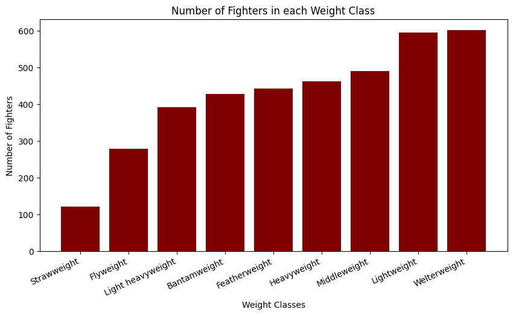

```python
fig = plt.figure(figsize = (10, 5))

plt.bar(result['weight_class'], result['count'], color ='maroon',
        width = 0.8)

plt.xlabel("Weight Classes")
plt.xticks(rotation = 25, ha='right')
plt.ylabel("Number of Fighters")
plt.title("Number of Fighters in each Weight Class")
plt.show()
```

From looking at the list of weught classes and the bar plot, we can see that welterweight and lightweight have the most fighters. We also see that straweight and flyweight have the least amount of fighters, but the difference between them is around 150 fighters. These numbers make sense as strawweight only has women and flyweight is the lightest weightclass for men. Lightweight and welterweight having the most fighters makes sense as they are the weight classes in the very middle where the average size person would be.

Now that we have found out how many fighters are in each weight class, lets determine if there is any relationship with the height and weight of the fighters.

```python
classes = df['weight_class'].unique()
```

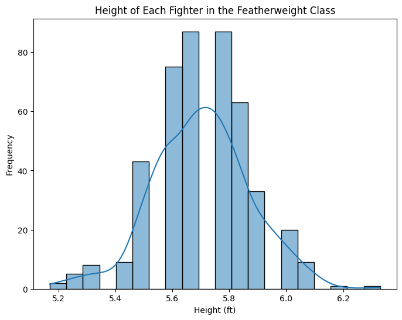

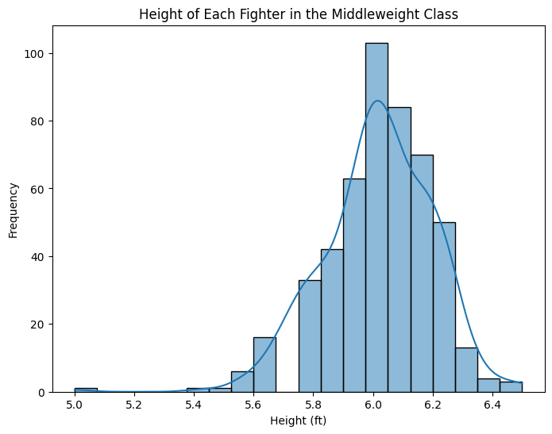

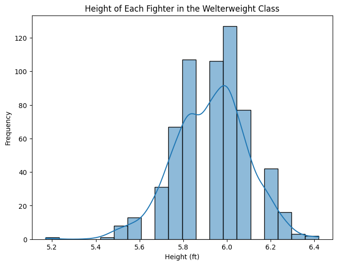

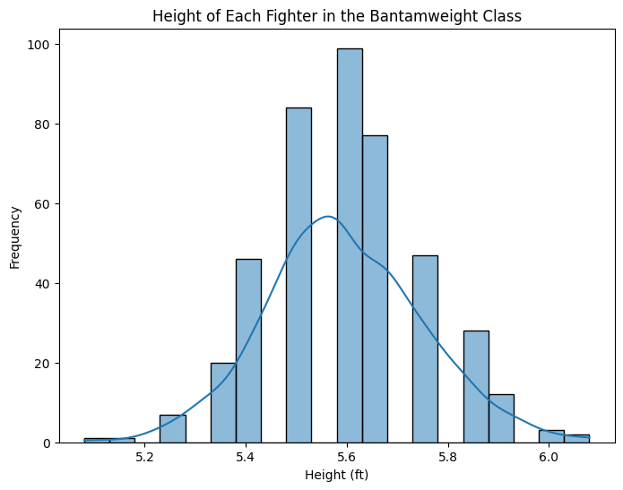

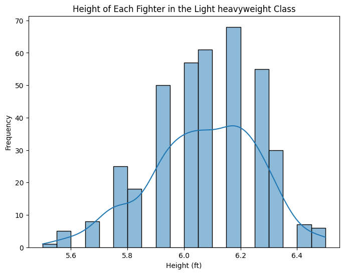

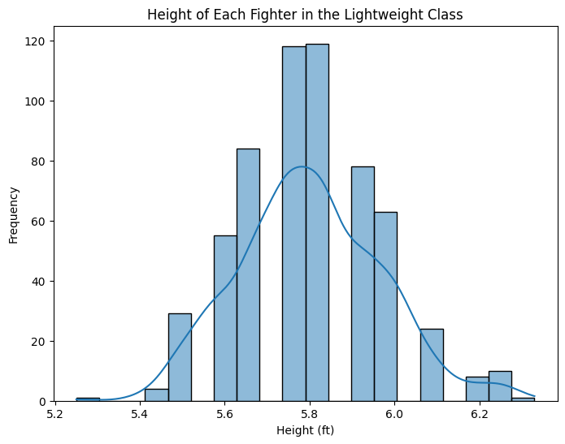

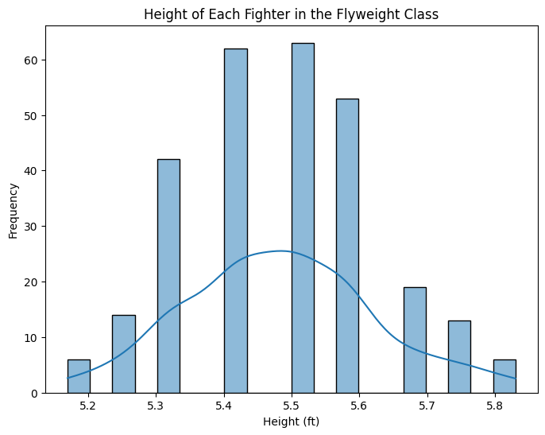

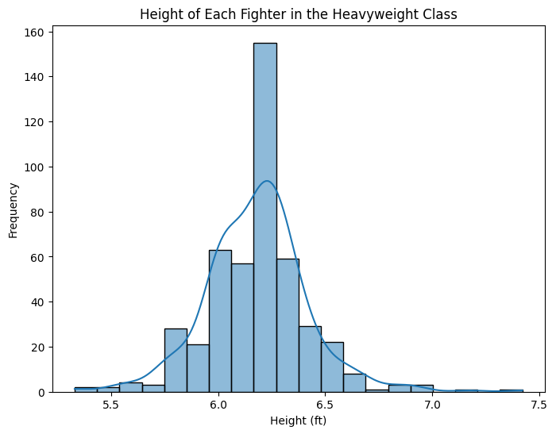

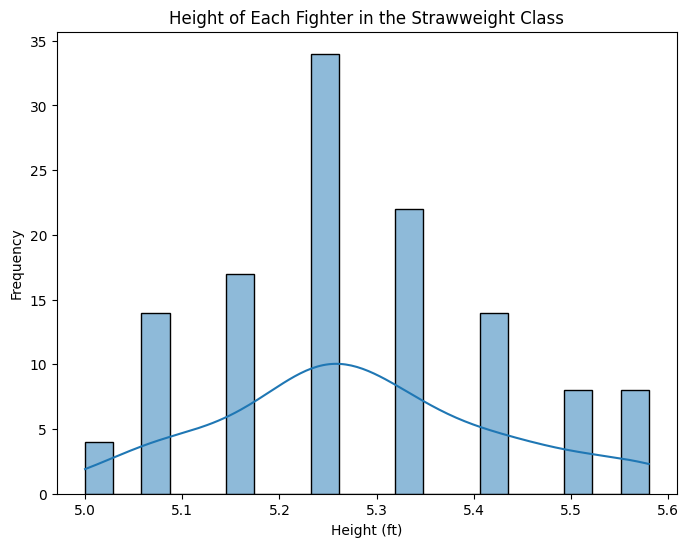

```python
for weight in classes:
  df1 = df[df['weight_class'] == weight]

  fig, axes = plt.subplots(1, 1, figsize=(8, 6))

  sns.histplot(df1['height_ft'], bins=20, kde=True, ax=axes)
  axes.set_title(f"Height of Each Fighter in the {weight} Class")
  axes.set_xlabel('Height (ft)')
  axes.set_ylabel('Frequency')

  plt.show()
```

Looking at the relationship between height and weight we can see that as the weight classes increase, the height at the peak of the bell curve increases as well.

Now lets take a look at the winning percentage. First we are going to look at the distribution of winning percentage among all fighters.

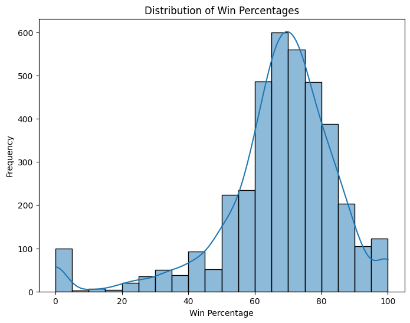

```python
fig, axes = plt.subplots(1, 1, figsize=(8, 6))

sns.histplot(df['win_percentage'], bins=20, kde=True, ax=axes)
axes.set_title('Distribution of Win Percentages')
axes.set_xlabel('Win Percentage')
axes.set_ylabel('Frequency')

plt.show()
```

From this histogram, we can see that most of the fighters have a win percentage between 60% and 80%, and the amount of fighters with a win percentage less than 50 is much less than the amount of fighters with a win percentage higher than 50. This is interesting as I thought that there would many more fighters with a lower win percentage, but after thinking about it more it makes sense that most fighters have a higher win percentage. It makes sense because the worse fighters end up getting bootted out of the UFC as the UFC is only for the best fighters in the world.

Now, lets see if there is a relationship between wins and win percentage. Just because someone has a lot of wins might not mean that they have a very high win percentage as they might have just fought in a lot of fights.

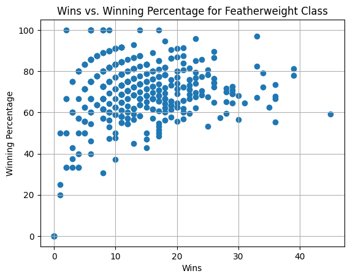

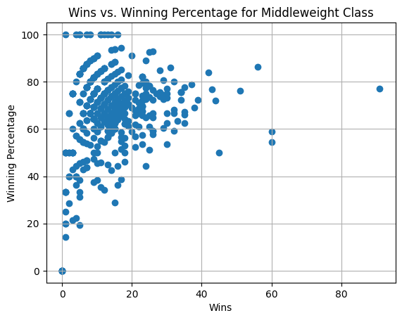

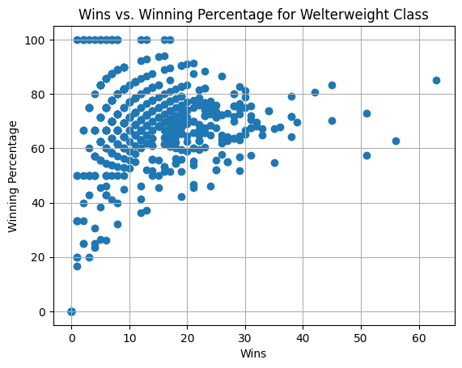

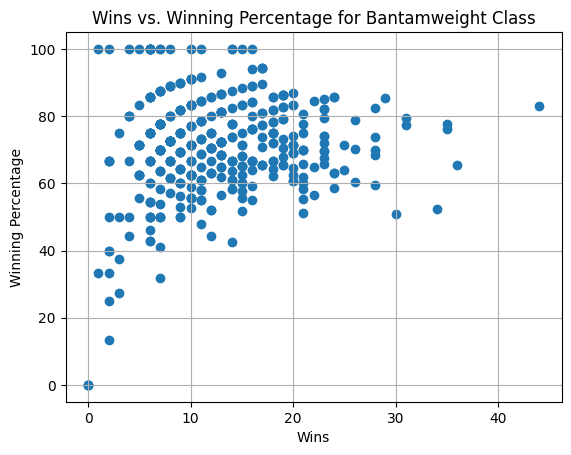

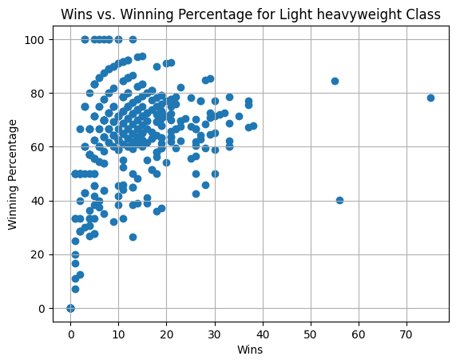

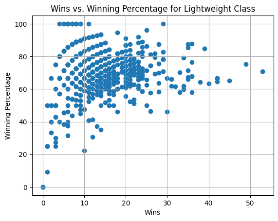

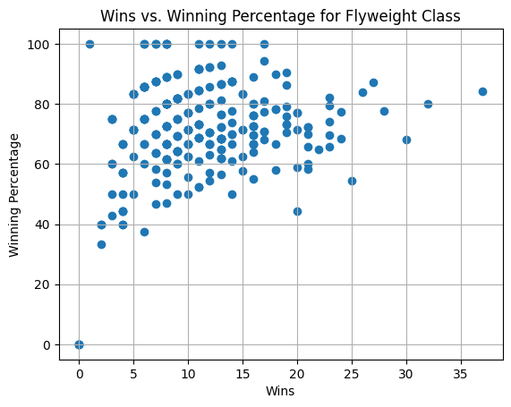

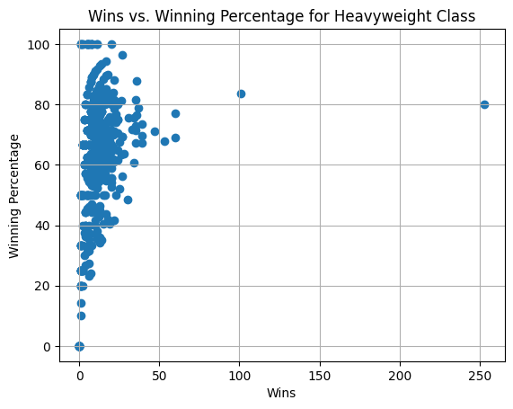

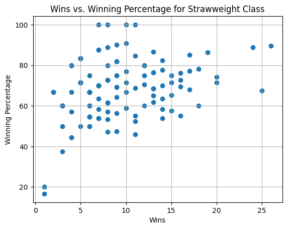

```python
for weight in classes:
  x = df.groupby('weight_class').get_group(weight)['wins']
  y = df.groupby('weight_class').get_group(weight)['win_percentage']
  plt.scatter(x,y)
  plt.title(f"Wins vs. Winning Percentage for {weight} Class")
  plt.xlabel('Wins')
  plt.ylabel('Winning Percentage')
  plt.grid(True)
  plt.show()
```

From the scatter plots it generally seems that as wins increase the win percentage of the worst fighters also increases.

Just because I am curious, lets see who the fighters with the most wins are in each weight class

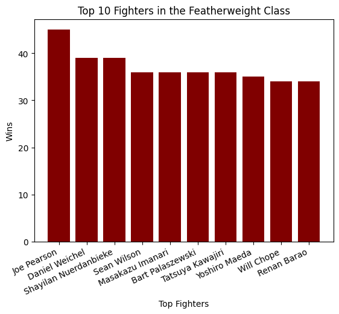

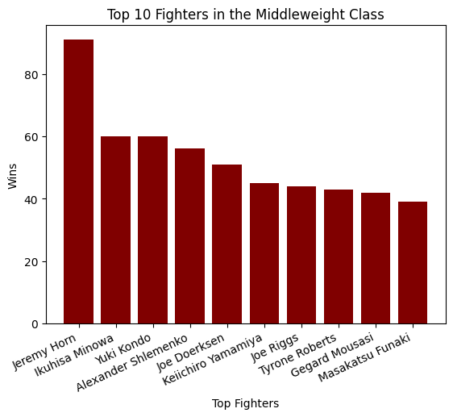

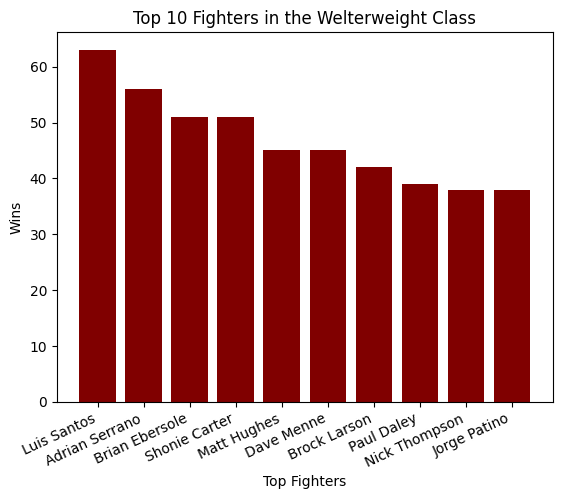

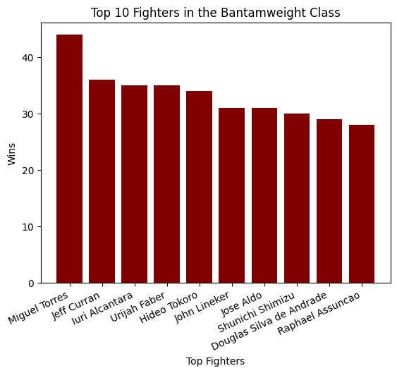

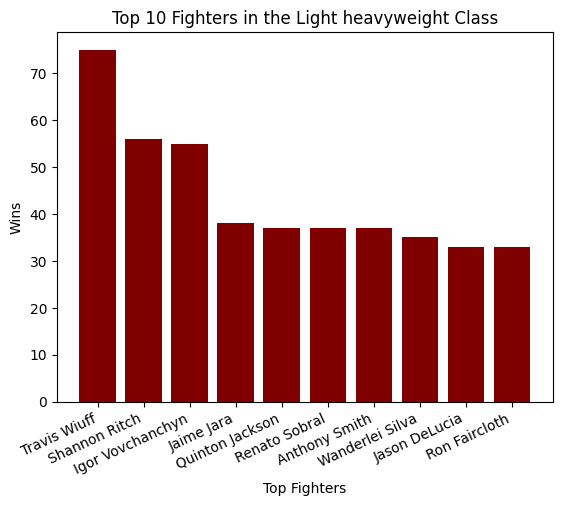

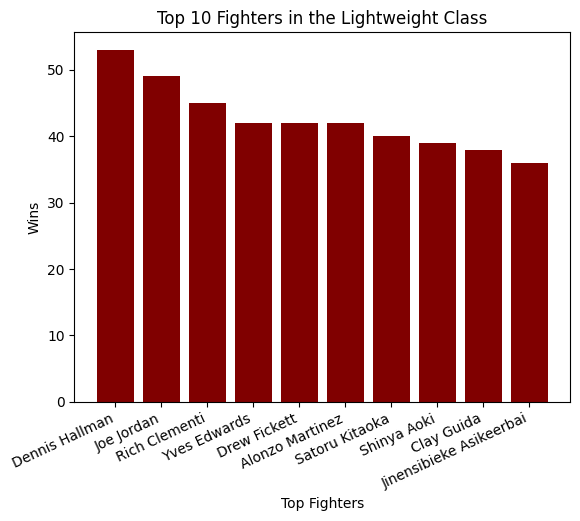

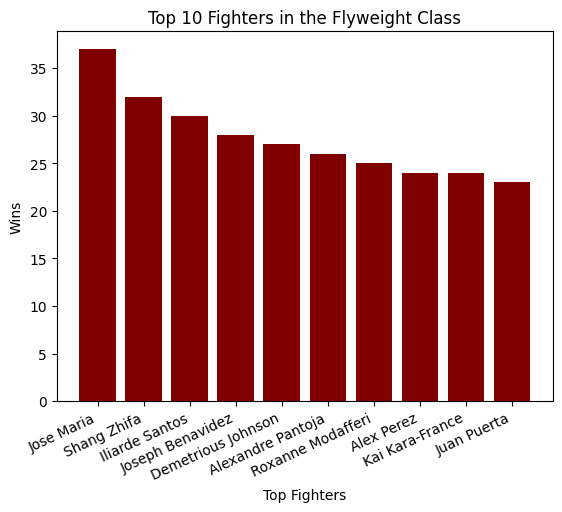

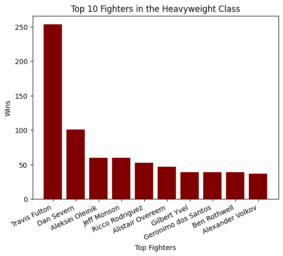

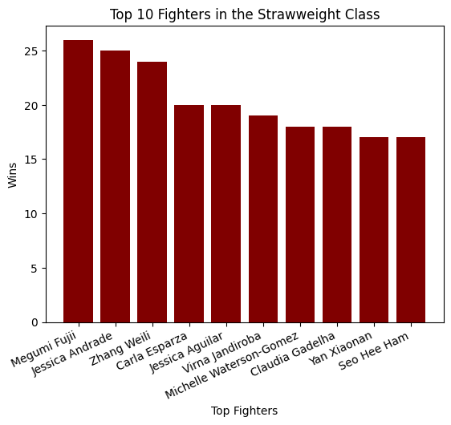

```python
for weight in classes:
  df1 = df[df['weight_class'] == weight]
  df1 = df1.sort_values(by = 'wins',ascending = False).head(10)
  plt.bar(df1['name'], df1['wins'], color ='maroon', width = 0.8)

  plt.xlabel("Top Fighters")
  plt.xticks(rotation = 25, ha='right')
  plt.ylabel("Wins")
  plt.title(f"Top 10 Fighters in the {weight} Class")
  plt.show()
```

While looking at each of the fighters something that I noticed was the fighter with the most wins in the heavyweight class. The fighter is Travis Fulton and he has over 250 wins which is insane. I did not even know that there were fighters who fought 250 times. While there are many fighter I do recognize, most of the fighters listed are fighters I have not heard of before. This could be because I started paying attention to the UFC a few years ago or becuase some of these fighters never really made it near the top of their weight class.

The body type is different for every fighter. Each fighter has a different height, reach, and fighing stance. From these characteristics, lets see if there is a relationship between each of them and the fighters' win percentage. First, we'll find if there is a relationship between height and win percentage.

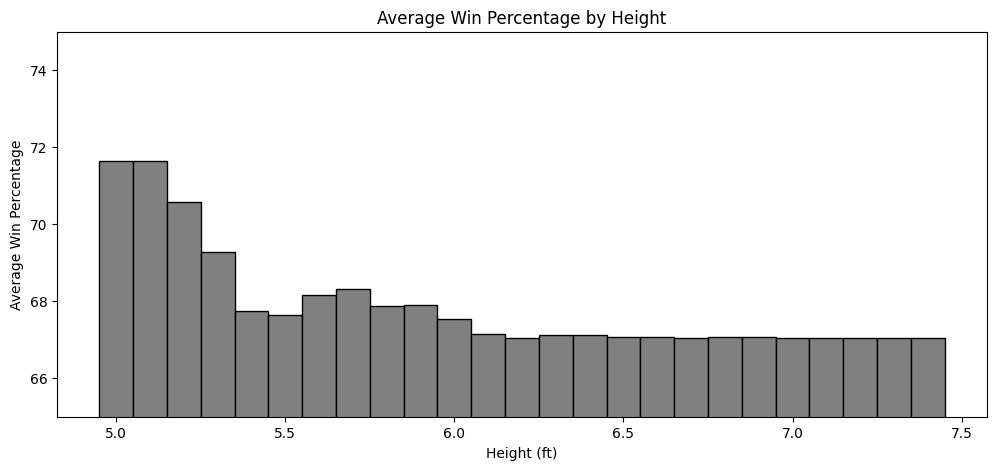

```python
fig = plt.figure(figsize = (12, 5))
val = df['height_ft'].min()
df_height = df[(df['height_ft'] >= val) & (df['height_ft'] < (val+0.1))]
d = {'height': [val],'avg': [df_height['win_percentage'].mean()]}
grp = pd.DataFrame(d)
val = val + 0.1
while val <= df['height_ft'].max():
  df_height = df[(df['height_ft'] <= val) & (df['height_ft'] < (val+0.1))]
  d = {'height': val,'avg': df_height['win_percentage'].mean()}
  grp = grp._append(d,ignore_index = True)
  val = val + 0.1

plt.bar(grp['height'],grp['avg'], color ='gray',
        width = 0.1, edgecolor= 'black')
plt.title('Average Win Percentage by Height')
plt.xlabel('Height (ft)')
plt.ylabel('Average Win Percentage')
plt.ylim(65,75)
plt.show()
```

It looks like people who are shorter tend to win more and people around five feet tall have the highest win percentage. Once the fighters' heights get above six feet tall then the win percentage does not change. While there does seem to be a relationship between height and win percentage, lets see if there is also a relationship between the reach of the fighters and win percentage

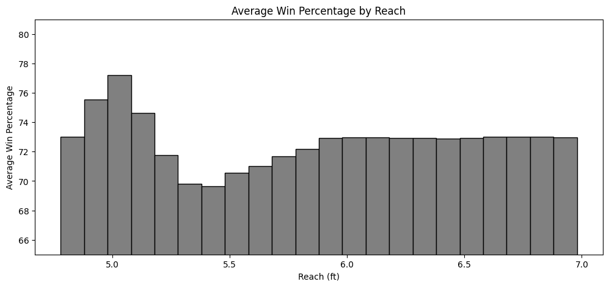

```python
fig = plt.figure(figsize = (12, 5))
df_reach = df.loc[~df['reach_ft'].isna()]
val = df_reach['reach_ft'].min()
df_r = df_reach[(df_reach['reach_ft'] >= val) & (df_reach['reach_ft'] < (val+0.1))]
d = {'reach': [val],'avg': [df_reach['win_percentage'].mean()]}
grp = pd.DataFrame(d)
val = val + 0.1
while val <= df['reach_ft'].max():
  df_r = df_reach[(df_reach['reach_ft'] <= val) & (df_reach['reach_ft'] < (val+0.1))]
  d = {'reach': val,'avg': df_r['win_percentage'].mean()}
  grp = grp._append(d,ignore_index = True)
  val = val + 0.1

plt.bar(grp['reach'],grp['avg'], color ='gray',
        width = 0.1, edgecolor= 'black')
plt.title('Average Win Percentage by Reach')
plt.xlabel('Reach (ft)')
plt.ylabel('Average Win Percentage')
plt.ylim(65,81)
plt.show()
```

The information that the bar plot gives is not what I expected at all. Fighters with a reach around five feet have an above average win percentage, but it then starts to dip and is below average around five and a half feet. a reason that this might be is due to the difference is size of fighters between weight classes. Fighters who have a shorter reach within the weight class might not be a successful. Along with height and reach, fighting stance might have some relationship with win percentage.

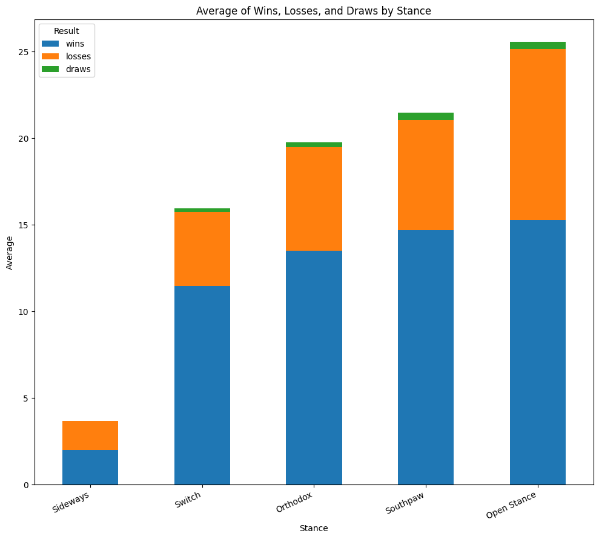

```python
df_stance = df.loc[~df['stance'].isna()]
grp = df_stance.groupby('stance')[['wins','losses','draws']].mean().sort_values(by = 'wins')
grp.plot(kind='bar',figsize =(10,9),stacked =True)
plt.title('Average of Wins, Losses, and Draws by Stance')
plt.xlabel('Stance')
plt.xticks(rotation = 25, ha='right')
plt.ylabel('Average')
plt.legend(title='Result')
plt.tight_layout()
plt.show()
```

After looking at the data, fighting stance does not really have any relationship with win percentage.

Key factors in determining who the best fighters in the UFC are, is striking, takedowns, and submissions. There are many different styles of fighters. Some may be strikers while others may dominate the ground game with takedowns and submissions. What we are going to do is try and see if there are any patterns or trends within these attributes that will lead to a greater win percentage.